# Aside

[Download in PDF](https://cv.ruizsergio.com/resume.pdf)

## Contact

- sruizcarmona@gmail.com
- sruizcarmona
- [Sergio Ruiz](https://www.linkedin.com/in/ruizcsergio/)
- ruizsergio.com

## Programming

R

Python

SQL

Web Development

C++

## Highlights

Highly experienced in:

- Computational biology and drug design
- Bioinformatics and biostatistics
- Machine Learning
- Data visualization
- Experimental techniques

Motivated and **collaborative**, recently involved in **Machine Learning**, NGS data analysis, **UK Biobank** and genomics prediction

## More info

See full CV at [cv.ruizsergio.com](http://cv.ruizsergio.com/full) for a complete list of positions, publications and more

**Reference contact details provided upon request**

## Disclaimer

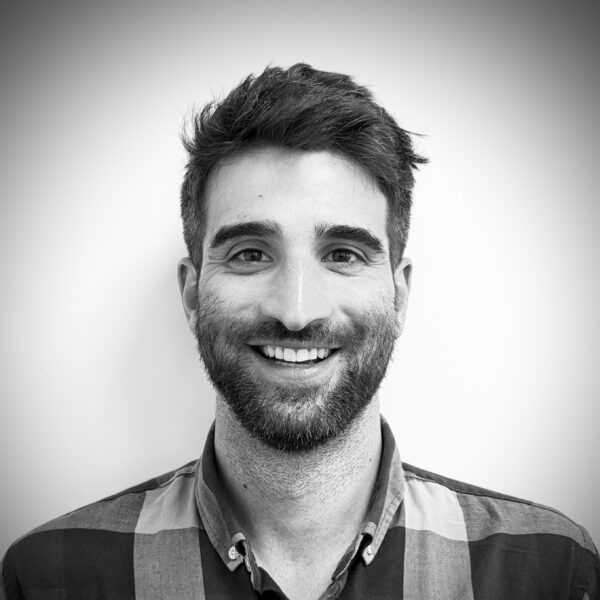

Source code available in [github](https://github.com/sruizcarmona/sergioruiz_cv)

Last updated in Aug, 2025

# Main

## Selected Education

### PhD in Biomedicine

Universitat de Barcelona

Barcelona, ES

Jan 2017 - Jul 2012

- Virtual Screening for novel MoA: Apps. and method developments
- Development and application of **structure-based drug discovery** methods
- Awards: **Extraordinary prize** for PhD Thesis and **Ramon Margalef award** for best publication

### MSc in Bioinformatics for Health Sciences

Universitat Pompeu Fabra

Barcelona, ES

Jun 2012 - Sep 2010

- Expanding Druggable Genome: PP-Interfaces as a new target class
- Study of novel rational approach to find PP interfacial binders

### BSc in Biotechnology

Universitat Autònoma de Barcelona

Barcelona, ES

Jun 2010 - Sep 2006

## Work History

### Data Analyst

Center for Child Health Analytics  
Luzerner Kantonsspital

Luzern, CH

Present - Mar 2025

- I turn clinical data into actionable insights to support evidence-based decisions. Experienced in extracting Epic EMR records using SQL and analyzing and visualizing data with R and Power BI, I help drive better healthcare outcomes.

### Clinical Data Analyst

Centre for Health Analytics  
Royal Children’s Hospital

Melbourne, AUS

Feb 2025 - Oct 2022

### Senior Research Officer and Bioinformatician

Inouye Lab  
Baker Heart and Diabetes Institute

Melbourne, AUS

Oct 2022 - Jan 2019

- I worked in the intersection between Structural Biology and Genomics, trying to understand how rare missense variants alter protein structures and can induce disease

### Postdoctoral Researcher

Barril Lab, Universitat de Barcelona

Barcelona, ES

Dec 2019 - Jan 2017

- After finishing my PhD, I worked in exciting collaborative projects in the field of epigenetics and cancer, where I carried out multidisciplinary research and learned new experimental skills

## Skills and Training

### Computational Tools

Data visualization, Data analysis, Dashboards (Power BI, R Shiny), CI/CD, Machine learning, Statistical analysis, REDCap, Bioinformatics and Drug Discovery

### Programming

R, Python, SQL, Perl, C++, LaTeX, Bash, Java, HTML/CSS and Android and Web Development

### Management Skills

2021 EMBO Practical Course: Research to service: Planning and running a bioinformatics core facility; Mental Health and OHS certifications

### Certifications

Certified Health Informatician Australasia (CHIA), UX/UI Design (RMIT), Dataviz with R (IBM), Machine Learning (IBM)

## Outreach and other activities

### [Australasian Leadership Computing Grants](https://nci.org.au/research/research-highlights/special-announcement-alcg-covid-19-special-call-recipients)

Story about NCI Computing Grant

Sep 2021 - Sep 2020

- Together with Mike Inouye, we were awarded a 1 year computing grant by the Australian National Computational Infrastructure to study COVID-19 proteins and possible drug treatments

### New tools for new medicines, The Conversation [article](https://baker.edu.au/news/in-the-media/discovery-new-medicines)

Lay-summary of some of my work and opinion for The Conversation Spain

Sep 2021

### [Shiny App](https://bakersportscardiology.shinyapps.io/fitoxy/) development

Related to a project we published in the Journal *Circulation*

Apr 2021

### COVID-19 daily [dashboard](https://www.ruizsergio.com/covid/), until Nov 2020

Personal project to showcase COVID-19 evolution in Victoria during major lockdown in 2020

Dec 2020

## Main Scientific Output

### COVID-19 thromboembolism is reduced in ambulatory, but not hospitalized patients, following COVID-19 vaccination

*Hematologica*  
Read it [here](https://haematologica.org/article/view/haematol.2022.282262)

Nov 2023

- Hannah Stevens *, **Sergio Ruiz-Carmona ***, Karlheinz Peter and James D McFadyen

### Oxygen Pathway Limitations in Patients with Chronic Thromboembolic Pulmonary Hypertension

*Circulation*  
Read it [here](https://www.ahajournals.org/doi/abs/10.1161/CIRCULATIONAHA.120.052899)

Apr 2021

- Erin J Howden *, **Sergio Ruiz-Carmona ***, […] Andre La Gerche, Marion Delcroix and Guido Claessen
- Result of a Bioinformatics Core collaboration. [Shiny app](https://bakersportscardiology.shinyapps.io/fitoxy/) developed

### Dynamic undocking and the quasi-bound state as tools for drug discovery

*Nature Chemistry*  
Read it [here](https://www.nature.com/articles/nchem.2660)

Jan 2017

- **Sergio Ruiz-Carmona**, Peter Schmidtke, […] Rod Hubbard and Xavier Barril
- **Highlighted in its [issue cover](https://www.nature.com/nchem/volumes/9/issues/3)**

### rDock: a fast, versatile and open source program for docking ligands to proteins and nucleic acids

*PLoS Computational Biology*  
Read it [here](https://journals.plos.org/ploscompbiol/article?id=10.1371/journal.pcbi.1003571)

Sep 2014

- **Sergio Ruiz-Carmona**, Daniel Alvarez-Garcia, […] Xavier Barril, Rod Hubbard and S David Morley

# Aside2

## Everyday toolbox

- RStudio
- Data viz & Shiny dashboards
- Bash, ssh & GitHub (local or HPC)
- ML optimization (genetic algorithms, MC, …)
- Linear models & random forests

## Web

I have also developed [rDock](http://rdock.sourceforge.net/) and [Barril Lab](http://www.ub.edu/bl/) websites, used as dissemination platforms where the different tutorials and blog entries are shared with the community

I have been involved in more than 20 collaborative projects in very different fields. I enjoy helping other researchers and collaborators to work in common scientific challenges

My ultimate goal is to help people: from drug discovery to precision medicine and hospital care data analysis

Part of my research in drug discovery became a [drug patent](https://patents.google.com/patent/EP4079304A1/en?oq=EP4079304A1) for cancer treatment, currently under development at [Oniria Therapeutics](https://www.oniriatherapeutics.com)